# Lung Cancer Data Analysis Report

Irgya Genta Arnezzi

2024-06-16

# Introduction

## Purpose and Context

This report presents a comprehensive analysis of lung cancer survival data. The primary objective is to identify factors influencing patient survival and to understand the significance of various clinical and demographic variables.

## Importance

Understanding the factors that affect lung cancer survival can guide clinical decision-making, inform policy, and improve patient outcomes. This analysis provides insights that can help in tailoring treatments and improving prognosis.

## Audience

This report is intended for researchers, healthcare professionals, and stakeholders interested in lung cancer treatment and survival outcomes.

## Objectives

- To identify key factors influencing lung cancer survival.
- To assess the statistical significance of these factors.
- To provide visualizations and interpretative insights from the data.

## Methods

We employ Exploratory Data Analysis (EDA), Kaplan-Meier survival curves, and Cox proportional hazards modeling to analyze the data.

## Assumptions and Limitations

- The dataset is assumed to be representative of the broader population.
- The analysis is limited by the variables available in the dataset.
- Censoring is inferred based on the survival months.

## Relevance

This analysis is crucial for improving lung cancer treatment strategies and understanding patient prognosis.

# Data Description

The dataset comprises various clinical and demographic variables related to lung cancer patients. Below are the key variables:  
- **Patient_ID**: Unique identifier for each patient.  
- **Age**: Age of the patient.  
- **Gender**: Gender of the patient.  
- **Smoking_History**: History of smoking (Yes/No).  
- **Tumor_Size_mm**: Size of the tumor in millimeters.  
- **Tumor_Location**: Location of the tumor.  
- **Stage**: Stage of cancer.  
- **Treatment**: Type of treatment received.  
- **Survival_Months**: Duration of survival or follow-up in months.  
- **Ethnicity**: Ethnicity of the patient.  
- **Insurance_Type**: Type of insurance coverage.  
- **Family_History**: Family history of lung cancer.  
- **Comorbidities**: Presence of various comorbidities.  
- **Performance_Status**: Performance status of the patient.  
- **Blood_Pressure**: Systolic, Diastolic, and Pulse pressure measurements.  
- **Laboratory Values**: Hemoglobin level, White blood cell count, Platelet count, etc.

# Data Preprocessing

```r
# Load necessary libraries
library(tidyverse)
library(Hmisc)
library(survival)
library(survminer)
```

```r
library(corrplot)
# Load the dataset
lung_cancer_data <- read.csv("/Users/irgyaarnezzi/Documents/Project Portfolio/Lung Cancer Data Analysis/lung_cancer_data.csv")

# Check for missing values
missing_values <- sapply(lung_cancer_data, function(x) sum(is.na(x)))
print(missing_values)
```

```
##                       Patient_ID                              Age
##                                0                                0
##                           Gender                  Smoking_History
##                                0                                0
##                    Tumor_Size_mm                   Tumor_Location
##                                0                                0
##                            Stage                        Treatment
##                                0                                0
##                  Survival_Months                        Ethnicity
##                                0                                0
##                   Insurance_Type                   Family_History
##                                0                                0
##             Comorbidity_Diabetes         Comorbidity_Hypertension
##                                0                                0
##        Comorbidity_Heart_Disease Comorbidity_Chronic_Lung_Disease
##                                0                                0
##       Comorbidity_Kidney_Disease   Comorbidity_Autoimmune_Disease
##                                0                                0
##                Comorbidity_Other               Performance_Status
##                                0                                0
##          Blood_Pressure_Systolic         Blood_Pressure_Diastolic
##                                0                                0
##             Blood_Pressure_Pulse                 Hemoglobin_Level
##                                0                                0
##           White_Blood_Cell_Count                   Platelet_Count
##                                0                                0
##                    Albumin_Level       Alkaline_Phosphatase_Level
##                                0                                0
##   Alanine_Aminotransferase_Level Aspartate_Aminotransferase_Level
##                                0                                0
##                 Creatinine_Level                        LDH_Level
##                                0                                0
##                    Calcium_Level                 Phosphorus_Level
##                                0                                0
##                    Glucose_Level                  Potassium_Level
##                                0                                0
##                     Sodium_Level               Smoking_Pack_Years
##                                0                                0
```

```r
# Impute missing values (example using median for numeric variables)
lung_cancer_data <- lung_cancer_data %>%
  mutate_at(vars(Age, Tumor_Size_mm, Survival_Months, Hemoglobin_Level, White_Blood_Cell_Count, Platelet_Count, Albumin_Level, Alkaline_Phosphatase_Level, Alanine_Aminotransferase_Level, Aspartate_Aminotransferase_Level, Creatinine_Level, LDH_Level, Calcium_Level, Phosphorus_Level, Glucose_Level, Potassium_Level, Sodium_Level, Smoking_Pack_Years),
            ~ifelse(is.na(.), median(., na.rm = TRUE), .))

# Create the Status variable
max_follow_up <- max(lung_cancer_data$Survival_Months, na.rm = TRUE)
lung_cancer_data <- lung_cancer_data %>%
  mutate(Status = ifelse(Survival_Months == max_follow_up, 0, 1))

# Verify the transformation
table(lung_cancer_data$Status)
```

```
##
##     0     1
##   205 23453
```

# Data Exploration

## Summary Statistics

```r
summary(lung_cancer_data)
```

```
##   Patient_ID             Age           Gender          Smoking_History
##  Length:23658       Min.   :30.00   Length:23658       Length:23658
##  Class :character   1st Qu.:42.00   Class :character   Class :character
##  Mode  :character   Median :54.00   Mode  :character   Mode  :character
##                     Mean   :54.44
##                     3rd Qu.:67.00
##                     Max.   :79.00
##  Tumor_Size_mm   Tumor_Location        Stage            Treatment
##  Min.   :10.00   Length:23658       Length:23658       Length:23658
##  1st Qu.:32.97   Class :character   Class :character   Class :character
##  Median :55.30   Mode  :character   Mode  :character   Mode  :character
##  Mean   :55.38
##  3rd Qu.:78.19
##  Max.   :99.99
##  Survival_Months   Ethnicity         Insurance_Type     Family_History
##  Min.   :  1.00   Length:23658       Length:23658       Length:23658
##  1st Qu.: 30.00   Class :character   Class :character   Class :character
##  Median : 60.00   Mode  :character   Mode  :character   Mode  :character
##  Mean   : 59.86
##  3rd Qu.: 89.00
##  Max.   :119.00
##  Comorbidity_Diabetes Comorbidity_Hypertension Comorbidity_Heart_Disease
##  Length:23658         Length:23658             Length:23658
##  Class :character     Class :character         Class :character
##  Mode  :character     Mode  :character         Mode  :character
##
##
##
##  Comorbidity_Chronic_Lung_Disease Comorbidity_Kidney_Disease
##  Length:23658                     Length:23658
##  Class :character                 Class :character
##  Mode  :character                 Mode  :character
##
##
##
##  Comorbidity_Autoimmune_Disease Comorbidity_Other  Performance_Status
##  Length:23658                   Length:23658       Min.   :0
##  Class :character               Class :character   1st Qu.:1
##  Mode  :character               Mode  :character   Median :2
##                                                    Mean   :2
```

[output cut: 29 more lines]

```
##  Max.   :50.00                    Max.   :1.5000   Max.   :250.0
##  Calcium_Level    Phosphorus_Level Glucose_Level    Potassium_Level
##  Min.   : 8.000   Min.   :2.500    Min.   : 70.00   Min.   :3.500
##  1st Qu.: 8.641   1st Qu.:3.120    1st Qu.: 89.83   1st Qu.:3.872
##  Median : 9.259   Median :3.731    Median :109.95   Median :4.242
##  Mean   : 9.261   Mean   :3.743    Mean   :109.90   Mean   :4.246
##  3rd Qu.: 9.883   3rd Qu.:4.364    3rd Qu.:130.06   3rd Qu.:4.618
##  Max.   :10.500   Max.   :5.000    Max.   :150.00   Max.   :5.000
##   Sodium_Level   Smoking_Pack_Years     Status
##  Min.   :135.0   Min.   :  0.0168   Min.   :0.0000
##  1st Qu.:137.5   1st Qu.: 25.0268   1st Qu.:1.0000
##  Median :140.0   Median : 49.9262   Median :1.0000
##  Mean   :140.0   Mean   : 49.9136   Mean   :0.9913
##  3rd Qu.:142.5   3rd Qu.: 74.9246   3rd Qu.:1.0000
##  Max.   :145.0   Max.   : 99.9995   Max.   :1.0000
```

## Data Visualizations

### Age Distribution

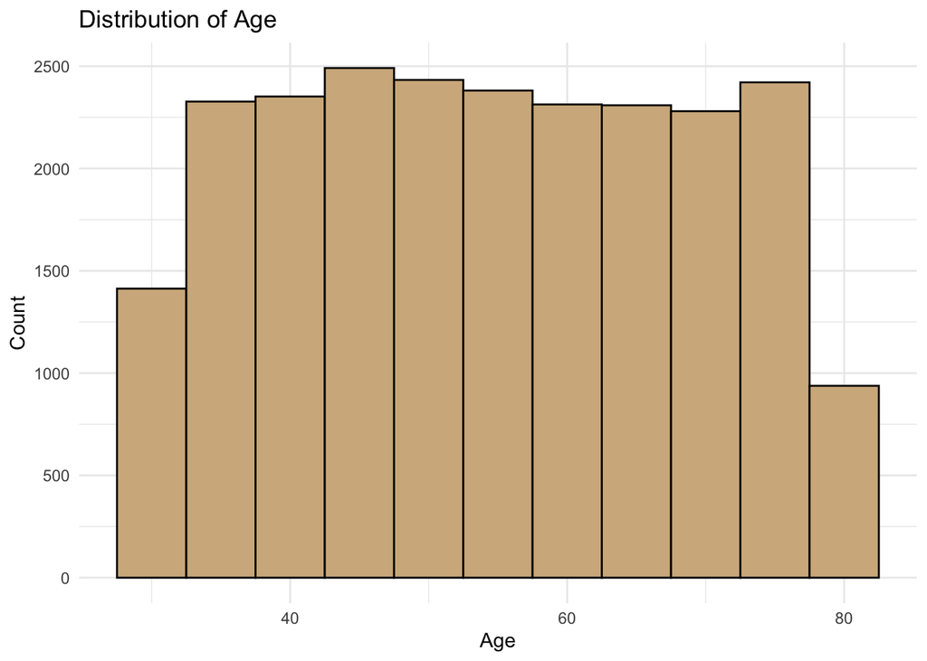

```r
ggplot(lung_cancer_data, aes(x = Age)) +
  geom_histogram(binwidth = 5, fill = "tan", color = "black") +
  theme_minimal() +
  labs(title = "Distribution of Age", x = "Age", y = "Count")
```

### Tumor Size by Stage

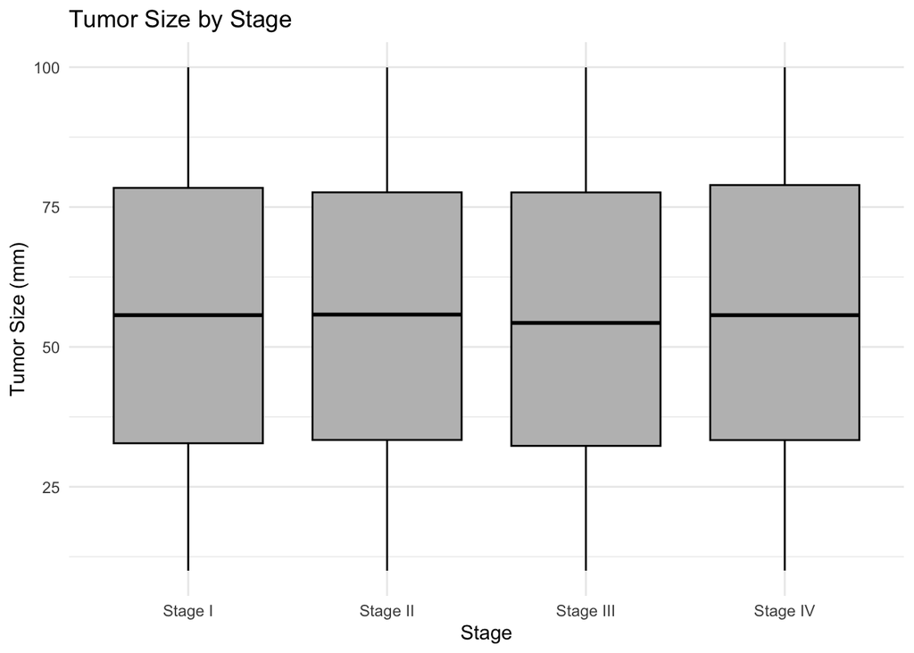

```r
ggplot(lung_cancer_data, aes(x = Stage, y = Tumor_Size_mm)) +
  geom_boxplot(fill = "grey", color = "black") +
  theme_minimal() +
  labs(title = "Tumor Size by Stage", x = "Stage", y = "Tumor Size (mm)")
```

### Correlation Analysis

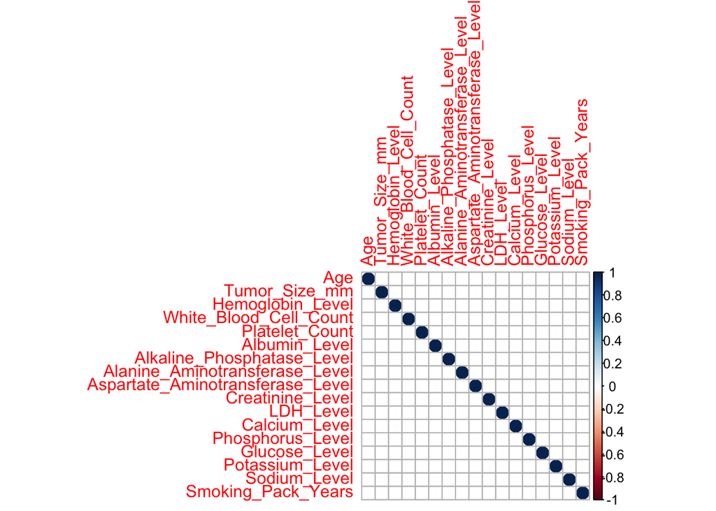

```r
# Correlation matrix
cor_matrix <- cor(lung_cancer_data %>% select(Age, Tumor_Size_mm, Hemoglobin_Level, White_Blood_Cell_Count, Platelet_Count, Albumin_Level, Alkaline_Phosphatase_Level, Alanine_Aminotransferase_Level, Aspartate_Aminotransferase_Level, Creatinine_Level, LDH_Level, Calcium_Level, Phosphorus_Level, Glucose_Level, Potassium_Level, Sodium_Level, Smoking_Pack_Years), use = "complete.obs")

# Plot the correlation matrix
corrplot(cor_matrix, method = "circle")
```

# Statistical Analysis

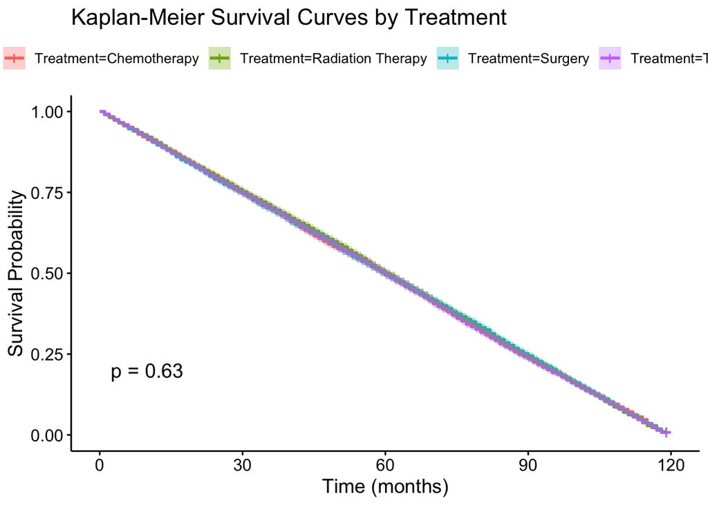

```r
# Kaplan-Meier survival curves by Treatment
km_fit_treatment <- survfit(Surv(Survival_Months, Status) ~ Treatment, data = lung_cancer_data)
ggsurvplot(km_fit_treatment, data = lung_cancer_data, pval = TRUE, conf.int = TRUE,
           title = "Kaplan-Meier Survival Curves by Treatment", xlab = "Time (months)", ylab = "Survival Probability")
```

## Cox Proportional Hazards Model

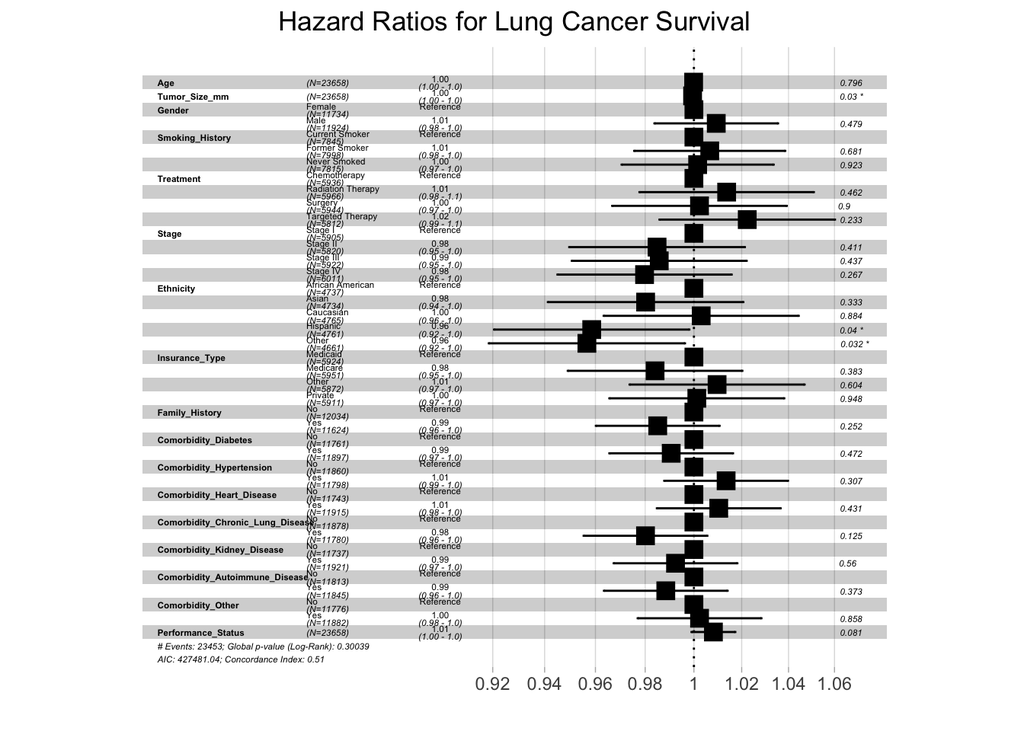

```r
# Fit the Cox model
cox_model <- coxph(Surv(Survival_Months, Status) ~ Age + Tumor_Size_mm + Gender + Smoking_History + Treatment + Stage + Ethnicity + Insurance_Type + Family_History + Comorbidity_Diabetes + Comorbidity_Hypertension + Comorbidity_Heart_Disease + Comorbidity_Chronic_Lung_Disease + Comorbidity_Kidney_Disease + Comorbidity_Autoimmune_Disease + Comorbidity_Other + Performance_Status, data = lung_cancer_data)

# Plot the forest plot
ggforest(cox_model, data = lung_cancer_data, fontsize = 0.4, refLabel = "Reference", noDigits = 2, main = "Hazard Ratios for Lung Cancer Survival")
```

```r
# Summary of the Cox model
summary(cox_model)
```

```
## Call:
## coxph(formula = Surv(Survival_Months, Status) ~ Age + Tumor_Size_mm +
##     Gender + Smoking_History + Treatment + Stage + Ethnicity +
##     Insurance_Type + Family_History + Comorbidity_Diabetes +
##     Comorbidity_Hypertension + Comorbidity_Heart_Disease + Comorbidity_Chronic_Lung_Disease +
##     Comorbidity_Kidney_Disease + Comorbidity_Autoimmune_Disease +
##     Comorbidity_Other + Performance_Status, data = lung_cancer_data)
##
##   n= 23658, number of events= 23453
##
##                                           coef  exp(coef)   se(coef)      z
## Age                                 -0.0001172  0.9998828  0.0004526 -0.259
## Tumor_Size_mm                       -0.0005473  0.9994528  0.0002519 -2.173
## GenderMale                           0.0092623  1.0093053  0.0130691  0.709
## Smoking_HistoryFormer Smoker         0.0065619  1.0065835  0.0159684  0.411
## Smoking_HistoryNever Smoked          0.0015471  1.0015483  0.0160721  0.096
## TreatmentRadiation Therapy           0.0135725  1.0136650  0.0184385  0.736
## TreatmentSurgery                     0.0023191  1.0023218  0.0184598  0.126
## TreatmentTargeted Therapy            0.0221040  1.0223501  0.0185510  1.192
## StageStage II                       -0.0152742  0.9848418  0.0185685 -0.823
## StageStage III                      -0.0143672  0.9857355  0.0184870 -0.777
## StageStage IV                       -0.0204507  0.9797570  0.0184139 -1.111
## EthnicityAsian                      -0.0200160  0.9801830  0.0206654 -0.969
## EthnicityCaucasian                   0.0030185  1.0030230  0.0206206  0.146
## EthnicityHispanic                   -0.0423578  0.9585268  0.0206419 -2.052
## EthnicityOther                      -0.0443570  0.9566123  0.0207406 -2.139
## Insurance_TypeMedicare              -0.0161005  0.9840284  0.0184586 -0.872
## Insurance_TypeOther                  0.0096035  1.0096498  0.0185003  0.519
## Insurance_TypePrivate                0.0012060  1.0012067  0.0184931  0.065
## Family_HistoryYes                   -0.0149942  0.9851176  0.0130778 -1.147
## Comorbidity_DiabetesYes             -0.0094122  0.9906320  0.0130731 -0.720
## Comorbidity_HypertensionYes          0.0133486  1.0134381  0.0130787  1.021
## Comorbidity_Heart_DiseaseYes         0.0102959  1.0103491  0.0130810  0.787
## Comorbidity_Chronic_Lung_DiseaseYes -0.0200653  0.9801347  0.0130771 -1.534
## Comorbidity_Kidney_DiseaseYes       -0.0076195  0.9924094  0.0130718 -0.583
## Comorbidity_Autoimmune_DiseaseYes   -0.0116558  0.9884119  0.0130715 -0.892
## Comorbidity_OtherYes                 0.0023375  1.0023403  0.0130807  0.179
## Performance_Status                   0.0080848  1.0081176  0.0046287  1.747
##                                     Pr(>|z|)
## Age                                   0.7956
```

[output cut: 47 more lines]

```
## Insurance_TypePrivate                  1.0012     0.9988    0.9656    1.0382
## Family_HistoryYes                      0.9851     1.0151    0.9602    1.0107
## Comorbidity_DiabetesYes                0.9906     1.0095    0.9656    1.0163
## Comorbidity_HypertensionYes            1.0134     0.9867    0.9878    1.0398
## Comorbidity_Heart_DiseaseYes           1.0103     0.9898    0.9848    1.0366
## Comorbidity_Chronic_Lung_DiseaseYes    0.9801     1.0203    0.9553    1.0056
## Comorbidity_Kidney_DiseaseYes          0.9924     1.0076    0.9673    1.0182
## Comorbidity_Autoimmune_DiseaseYes      0.9884     1.0117    0.9634    1.0141
## Comorbidity_OtherYes                   1.0023     0.9977    0.9770    1.0284
## Performance_Status                     1.0081     0.9919    0.9990    1.0173
##
## Concordance= 0.51  (se = 0.002 )
## Likelihood ratio test= 30.31  on 27 df,   p=0.3
## Wald test            = 30.31  on 27 df,   p=0.3
## Score (logrank) test = 30.31  on 27 df,   p=0.3
```